# Convolutional Neural Networks

## Project: Write an Algorithm for Landmark Classification

### Introduction

The project folder has the following structure:

- In the main directory you have this notebook, `cnn_from_scratch.ipynb`, that contains the instruction and some questions you will have to answer. Follow this notebook and complete the required sections in order.
- In the `src/` directory you have several source files. As instructed in this notebook, you will open and complete those files, then come back to this notebook to execute some tests that will verify what you have done. While these tests don't guarantee that your work is bug-free, they will help you finding the most obvious problems so you will be able to proceed to the next step with confidence.
- Sometimes you will need to restart the notebook. If you do so, remember to execute also the cells containing the code you have already completed starting from the top, before you move on.

In addition to implementing code, there will be questions that you must answer which relate to the project and your implementation. Each section where you will answer a question is preceded by a **'Question'** header. Carefully read each question and provide thorough answers in the following text boxes that begin with **'Answer:'**. Your project submission will be evaluated based on your answers to each of the questions and the implementation you provide.

[figure not shown]

> Code and Markdown cells can be executed using the **Shift + Enter** keyboard shortcut. Markdown cells can be edited by double-clicking the cell to enter edit mode.

The rubric contains *optional* "Stand Out Suggestions" for enhancing the project beyond the minimum requirements. If you decide to pursue the "Stand Out Suggestions", you should include the code in this Jupyter notebook.

### Designing and training a CNN from scratch

In this notebook, you will create a CNN that classifies landmarks. You must create your CNN *from scratch* (so, you can't use transfer learning *yet*!), and you must attain a test accuracy of at least 50%.

Although 50% may seem low at first glance, it seems more reasonable after realizing how difficult of a problem this is. Many times, an image that is taken at a landmark captures a fairly mundane image of an animal or plant, like in the following picture.

[figure not shown]

Just by looking at that image alone, would you have been able to guess that it was taken at the Haleakalā National Park in Hawaii?

An accuracy of 50% is significantly better than random guessing, which would provide an accuracy of just 2% (100% / 50 classes). In Step 2 of this notebook, you will have the opportunity to greatly improve accuracy by using transfer learning to create a CNN.

Experiment with different architectures, hyperparameters, training strategies, and trust your intuition. And, of course, have fun!

## Step 0: Setting up

[figure not shown]

The following cells make sure that your environment is setup correctly, download the data if you don't have it already, and also check that your GPU is available and ready to go. You have to execute them every time you restart your notebook.

```python
# Install requirements
!pip install -r requirements.txt | grep -v "already satisfied"
```

Important! After you have ran pip install, please restart the kernel using the **Kernel** menu

```python
from src.helpers import setup_env

# If running locally, this will download dataset (make sure you have at
# least 2 Gb of space on your hard drive)
setup_env()
```

```
GPU available
Dataset already downloaded. If you need to re-download, please delete the directory /data/DLND/C2/landmark_images
Reusing cached mean and std
```

## Step 1: Data

[figure not shown]

In this and the following steps we are going to complete some code, and then execute some tests to make sure the code works as intended.

Open the file `src/data.py`. It contains a function called `get_data_loaders`. Read the function and complete all the parts marked by `YOUR CODE HERE`. Once you have finished, test that your implementation is correct by executing the following cell (see below for what to do if a test fails):

```python
!pytest -vv src/data.py -k data_loaders
```

```
============================= test session starts ==============================
platform linux -- Python 3.7.6, pytest-7.1.1, pluggy-1.2.0 -- /opt/conda/bin/python3.7
cachedir: .pytest_cache
rootdir: /workspace/home
collected 4 items / 1 deselected / 3 selected

src/data.py::test_data_loaders_keys PASSED                               [ 33%]
src/data.py::test_data_loaders_output_type PASSED                        [ 66%]
src/data.py::test_data_loaders_output_shape PASSED                       [100%]

======================= 3 passed, 1 deselected in 5.52s ========================
```

[figure not shown]

**Question:** Describe your chosen procedure for preprocessing the data.

- How does your code resize the images (by cropping, stretching, etc)? What size did you pick for the input tensor, and why?
- Did you decide to augment the dataset? If so, how (through translations, flips, rotations, etc)? If not, why not?

[figure not shown]

**Answer**:

For preprocessing the data, I utilized various transformations to ensure that the input images are suitable for the machine learning model and augment the dataset to improve the generalization performance.

### Visualize a Batch of Training Data

Go back to `src/data.py` and complete the function `visualize_one_batch` in all places with the `YOUR CODE HERE` marker. After you're done, execute the following cell and make sure the test `src/data.py::test_visualize_one_batch` is `PASSED`:

```python
!pytest -vv src/data.py -k visualize_one_batch
```

```
============================= test session starts ==============================
platform linux -- Python 3.7.6, pytest-7.1.1, pluggy-1.2.0 -- /opt/conda/bin/python3.7
cachedir: .pytest_cache
rootdir: /workspace/home
collected 4 items / 3 deselected / 1 selected

src/data.py::test_visualize_one_batch PASSED                             [100%]

======================= 1 passed, 3 deselected in 5.36s ========================
```

We can now use the code we just completed to get a batch of images from your train data loader and look at them.

Visualizing the output of your data loader is a great way to ensure that your data loading and preprocessing (including transforms such as rotations, translations, color transforms...) are working as expected.

```
Reusing cached mean and std
Dataset mean: tensor([0.4638, 0.4725, 0.4687]), std: tensor([0.2699, 0.2706, 0.3018])
Reusing cached mean and std
```

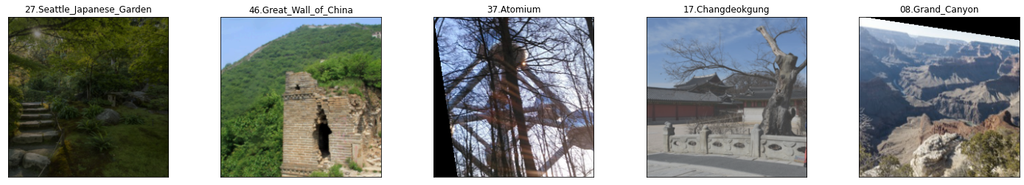

```python
%matplotlib inline
from src.data import visualize_one_batch, get_data_loaders

# use get_data_loaders to get the data_loaders dictionary. Use a batch_size
# of 5, a validation size of 0.01 and num_workers=-1 (all CPUs)
data_loaders = get_data_loaders(batch_size=5, valid_size=0.01, num_workers=0)

visualize_one_batch(data_loaders)
```

## Step 2: Define model

[figure not shown]

Open `src/model.py` and complete the `MyModel` class filling in all the `YOUR CODE HERE` sections. After you're done, execute the following test and make sure it passes:

```python
!pytest -vv src/model.py
```

```
============================= test session starts ==============================
platform linux -- Python 3.7.6, pytest-7.1.1, pluggy-1.2.0 -- /opt/conda/bin/python3.7
cachedir: .pytest_cache
rootdir: /workspace/home
collected 3 items

src/model.py::test_model_construction PASSED                             [ 33%]
src/model.py::test_model_feature_extractor PASSED                        [ 66%]
src/model.py::test_model_classifier PASSED                               [100%]

============================== 3 passed in 22.34s ==============================
```

[figure not shown]

**Question**: Outline the steps you took to get to your final CNN architecture and your reasoning at each step.

[figure not shown]

**Answer:**

## Step 3: define loss and optimizer

[figure not shown]

Open `src/optimization.py` and complete the `get_loss` function, then execute the test and make sure it passes:

```python
!pytest -vv src/optimization.py -k get_loss
```

```
============================= test session starts ==============================
platform linux -- Python 3.7.6, pytest-7.1.1, pluggy-1.2.0 -- /opt/conda/bin/python3.7
cachedir: .pytest_cache
rootdir: /workspace/home
collected 7 items / 6 deselected / 1 selected

src/optimization.py::test_get_loss PASSED                                [100%]

======================= 1 passed, 6 deselected in 1.91s ========================
```

Then, in the same file, complete the `get_optimizer` function then execute its tests, and make sure they all pass:

```python
!pytest -vv src/optimization.py -k get_optimizer
```

```
============================= test session starts ==============================
platform linux -- Python 3.7.6, pytest-7.1.1, pluggy-1.2.0 -- /opt/conda/bin/python3.7
cachedir: .pytest_cache
rootdir: /workspace/home
collected 7 items / 1 deselected / 6 selected

src/optimization.py::test_get_optimizer_type PASSED                      [ 16%]
src/optimization.py::test_get_optimizer_is_linked_with_model PASSED      [ 33%]
src/optimization.py::test_get_optimizer_returns_adam PASSED              [ 50%]
src/optimization.py::test_get_optimizer_sets_learning_rate PASSED        [ 66%]
src/optimization.py::test_get_optimizer_sets_momentum PASSED             [ 83%]
src/optimization.py::test_get_optimizer_sets_weight_decat PASSED         [100%]

======================= 6 passed, 1 deselected in 1.89s ========================
```

## Step 4: Train and Validate the Model

[figure not shown]

> Testing ML code is notoriously difficult. The tests in this section merely exercise the functions you are completing, so it will help you catching glaring problems but it won't guarantee that your training code is bug-free. If you see that your loss is not decreasing, for example, that's a sign of a bug or of a flawed model design. Use your judgement.

Open `src/train.py` and complete the `train_one_epoch` function, then run the tests:

```python
!pytest -vv src/train.py -k train_one_epoch
```

```
============================= test session starts ==============================
platform linux -- Python 3.7.6, pytest-7.1.1, pluggy-1.2.0 -- /opt/conda/bin/python3.7
cachedir: .pytest_cache
rootdir: /workspace/home
collected 4 items / 3 deselected / 1 selected

src/train.py::test_train_one_epoch PASSED                                [100%]

================== 1 passed, 3 deselected in 73.98s (0:01:13) ==================
```

Now complete the `valid` function, then run the tests:

```python
!pytest -vv src/train.py -k valid_one_epoch
```

```
============================= test session starts ==============================
platform linux -- Python 3.7.6, pytest-7.1.1, pluggy-1.2.0 -- /opt/conda/bin/python3.7
cachedir: .pytest_cache
rootdir: /workspace/home
collected 4 items / 3 deselected / 1 selected

src/train.py::test_valid_one_epoch PASSED                                [100%]

================== 1 passed, 3 deselected in 72.63s (0:01:12) ==================
```

Now complete the `optimize` function, then run the tests:

```python
!pytest -vv src/train.py -k optimize
```

```
============================= test session starts ==============================
platform linux -- Python 3.7.6, pytest-7.1.1, pluggy-1.2.0 -- /opt/conda/bin/python3.7
cachedir: .pytest_cache
rootdir: /workspace/home
collected 4 items / 3 deselected / 1 selected

src/train.py::test_optimize PASSED                                       [100%]

================= 1 passed, 3 deselected in 139.57s (0:02:19) ==================
```

Finally, complete the `test` function then run the tests:

```python
!pytest -vv src/train.py -k one_epoch_test
```

```
============================= test session starts ==============================
platform linux -- Python 3.7.6, pytest-7.1.1, pluggy-1.2.0 -- /opt/conda/bin/python3.7
cachedir: .pytest_cache
rootdir: /workspace/home
collected 4 items / 3 deselected / 1 selected

src/train.py::test_one_epoch_test PASSED                                 [100%]

================== 1 passed, 3 deselected in 71.54s (0:01:11) ==================
```

## Step 5: Putting everything together

[figure not shown]

Allright, good job getting here! Now it's time to see if all our hard work pays off. In the following cell we will train your model and validate it against the validation set.

Let's start by defining a few hyperparameters. Feel free to experiment with different values and try to optimize your model:

```python
import matplotlib.pyplot as plt


def plot_losses(train_losses, valid_losses):
    plt.figure(figsize=(10, 5))
    plt.plot(train_losses, label='Training Loss')
    plt.plot(valid_losses, label='Validation Loss')
    plt.xlabel('Epoch')
    plt.ylabel('Loss')
    plt.legend()
    plt.show()
```

```python
batch_size = 64        # size of the minibatch for stochastic gradient descent (or Adam)
valid_size = 0.2       # fraction of the training data to reserve for validation
num_epochs = 40       # number of epochs for training
num_classes = 50       # number of classes. Do not change this
dropout = 0.4          # dropout for our model
learning_rate = 0.0001  # Learning rate for SGD (or Adam)
opt = 'adam'            # optimizer. 'sgd' or 'adam'
weight_decay = 0.001     # regularization. Increase this to combat overfitting
```

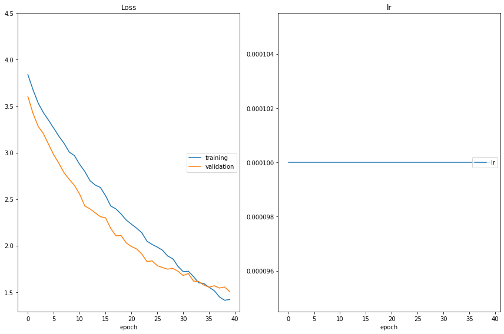

```python
import torch
from src.data import get_data_loaders
from src.train import optimize, one_epoch_test
from src.optimization import get_optimizer, get_loss
from src.model import MyModel

# Data Processing and Loading
data_loaders = get_data_loaders(batch_size=batch_size, valid_size=valid_size, num_workers=4)

# Model Initialization
model = MyModel(num_classes=num_classes, dropout=dropout)
print(model)
# Optimizer and Loss Initialization
optimizer = get_optimizer(
    model=model,
    optimizer=opt,  # 'adam' or 'sgd'
    learning_rate=learning_rate,
    weight_decay=weight_decay
)
loss = get_loss()

# Optimize and Train the Model
optimize(
    data_loaders,
    model,
    optimizer,
    loss,
    n_epochs=num_epochs,
    save_path="checkpoints/best_val_loss.pt",
    interactive_tracking=True
)
```

## Step 6: testing against the Test Set

[figure not shown]

> only run this *after* you have completed hyperpameter optimization. Do not optimize hyperparameters by looking at the results on the test set, or you might overfit on the test set (bad, bad, bad)

Run the code cell below to try out your model on the test dataset of landmark images. Ensure that your test accuracy is greater than 50%.

```python
# load the model that got the best validation accuracy
from src.train import one_epoch_test
from src.model import MyModel
import torch

model = MyModel(num_classes=num_classes, dropout=dropout)

checkpoint_path = 'checkpoints/best_val_loss.pt'
model.load_state_dict(torch.load(checkpoint_path))

# Run test
one_epoch_test(data_loaders['test'], model, loss)
```

[output not shown]

```
1.4005445510149002
```

## Step 7: Export using torchscript

[figure not shown]

Great job creating your CNN models! Now that you have put in all the hard work of creating accurate classifiers, let's export it so we can use it in our app.

But first, as usual, we need to complete some code!

Open `src/predictor.py` and fill up the missing code, then run the tests:

```python
!pytest -vv src/predictor.py
```

```
============================= test session starts ==============================
platform linux -- Python 3.7.6, pytest-7.1.1, pluggy-1.2.0 -- /opt/conda/bin/python3.7
cachedir: .pytest_cache
rootdir: /workspace/home
collected 1 item

src/predictor.py::test_model_construction PASSED                         [100%]

============================== 1 passed in 8.00s ===============================
```

Allright, now we are ready to export our model using our Predictor class:

```python
from src.predictor import Predictor
from src.helpers import compute_mean_and_std
from src.model import MyModel
from src.data import get_data_loaders
import torch

# Load the data loaders
data_loaders = get_data_loaders(batch_size=1)

# Get the class names from the training dataset
class_names = data_loaders["train"].dataset.classes

# Initialize the model and move it to CPU
model = MyModel(num_classes=50, dropout=0.5).cpu()

# Load the best weights we have found during training
model.load_state_dict(torch.load("checkpoints/best_val_loss.pt", map_location='cpu'))

# Compute the mean and standard deviation for normalization
mean, std = compute_mean_and_std()

# Wrap the model using the Predictor class
predictor = Predictor(model, class_names, mean, std)

# Export using torch.jit.script
scripted_predictor = torch.jit.script(predictor)

# Save the scripted model
scripted_predictor.save("checkpoints/original_exported.pt")
```

```
Reusing cached mean and std
Dataset mean: tensor([0.4638, 0.4725, 0.4687]), std: tensor([0.2699, 0.2706, 0.3018])
Reusing cached mean and std
```

Now let's make sure the exported model has the same performance as the original one, by reloading it and testing it. The Predictor class takes different inputs than the non-wrapped model, so we have to use a specific test loop:

```python
import torch

# Load using torch.jit.load
model_reloaded = torch.jit.load("checkpoints/original_exported.pt")
```

```python
from src.predictor import predictor_test

pred, truth = predictor_test(data_loaders['test'], model_reloaded)
```

```
Accuracy: 0.6048
```

Finally, let's have a look at the confusion matrix of the model we are going to use in production:

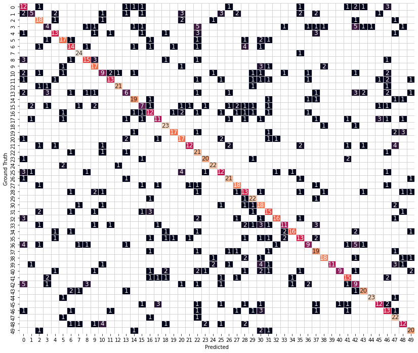

```python
from src.helpers import plot_confusion_matrix

plot_confusion_matrix(pred, truth)
```

```python
 jupyter nbconvert --to html *.ipynb
```